# CatsCradle Spatial Vignette

Anna Laddach and Michael Shapiro

2024-07-09

[figure not shown]

## Introduction

Here we describe the tools that CatsCradle offers for exploiting the spatial relationships in spatial transcriptomics data.

We will be using a subset of a Xenium data set that profiles the mouse hippocampus available from 10x genomics (https://www.10xgenomics.com/datasets/fresh-frozen-mouse-brain-for-xenium-explorer-demo-1-standard)

Here we visualise this subset coloured by cell type. Here cell clusters (Louvain cluster) have been assigned cell type identities using RCTD along with a reference dataset (https://www.dropbox.com/s/cuowvm4vrf65pvq/allen_cortex.rds?dl=1) followed by minimal manual curation. Please note these assignments are not definitive and are for illustratory purporses only.

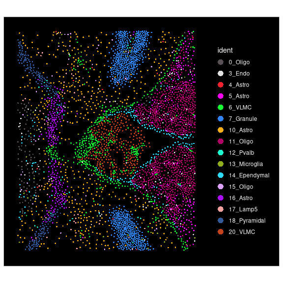

```r
library(Seurat,quietly=TRUE)
library(CatsCradle,quietly=TRUE)
ImageDimPlot(smallXenium, cols = "polychrome", size = 1)
```

We will want to answer questions like the following:

Is the expression of a particular gene localised? Who are the immediate neighbours of a given cell? Do certain types of cells tend to co-localise? Is the spatial association of two cell types, (say, glia and macrophages) statistically significant? For any pair of neighbouring cells, are they engaged in ligand-repceptor interactions? Can we classify different types of tissue neighbourhoods? Are different neighbourhood types characterised by the cell types found in them? The genes expressed in them? The ligand-receptor interactions taking place in them?

### Neighbourhoods

A key concept here is that of a *neighbourhood*. A neighbourhood is a spatially contiguous set of cells. In every case we will consider, a neighbourhood is a set of cells *centred on a particular cell*.

The simplest sort of neighbourhood consists of a cell together with its immediate neighbours. We compute these as a Delaunay triangulation using the centroids of the cells:

```r
centroids = GetTissueCoordinates(smallXenium)
rownames(centroids) = centroids$cell
clusters = smallXenium@active.ident
delaunayNeighbours = computeNeighboursDelaunay(centroids)
head(delaunayNeighbours)
```

```
#>   nodeA nodeB
#> 1 16307 16316
#> 2 16314 16317
#> 3 16296 16299
#> 4 16299 16307
#> 5 16309 16316
#> 6 16309 16314
```

Two cells are neighbours if they appear on the same row. The neighbourhood of the cell 16307 consists of the following 7 cells:

```r
idx = (delaunayNeighbours$nodeA == 16307 |
       delaunayNeighbours$nodeB == 16307)
nbhd = unique(c(delaunayNeighbours$nodeA[idx],
                delaunayNeighbours$nodeB[idx]))
nbhd
```

```
#> [1] "16307" "16299" "16303" "16298" "16296" "16316" "16317"
```

We can compute extended neighbourhoods by considering (say) each cell’s neighbours, their neighbours, their neighbours and their neighbours. Here we have such an extended neighbourhood as a list and again as a data frame with each row giving a pair of cells in a common extended neighbourhood. In this case we are building an extended neighbourhood of combinatorial radius 4.

```r
extendedNeighboursList = getExtendedNBHDs(delaunayNeighbours, 4)
```

```
#> radius 2
#> radius 3
#> radius 4
```

```r
extendedNeighbours = collapseExtendedNBHDs(extendedNeighboursList, 4)
```

Now the extended neighbourhood of cell 16307 consists of 92 cells:

```r
idx = (extendedNeighbours$nodeA == 16307 |
       extendedNeighbours$nodeB == 16307)
nbhd = unique(c(extendedNeighbours$nodeA[idx],
                extendedNeighbours$nodeB[idx]))
length(nbhd)
```

```
#> [1] 92
```

We can also create neighbours based on Euclidean distance in the tissue.

```r
euclideanNeighbours = computeNeighboursEuclidean(centroids,
threshold=20)
```

We see two reasons for looking at these extended neighbourhoods. One is that while the Delaunay triangulation might be more appropriate for looking at cell to cell interactions involving direct contact, extended neighbourhoods might be more appropriate for studying interactions based on diffusible ligands. The second is that when we go on to characterise *types* of neighbourhoods, these extended neighbourhoods exhibit less noise.

We offer two viewpoints as to what is “going on” in a neighbourhood. One is that a neighbourhood is characterised by the cell types that are found in it. In this view, just as a cell expresses genes, a neighbourhood “expresses” cell types. A second viewpoint is that a neighbourhood also expresses genes. That is, for each neighbourhood, we can compute the total gene expression across all the cells in that neighbourhood.

In this vignette we will focus on the first viewpoint. This is not because we think the first viewpoint is more important or because we necessarily expect it to be more fruitful. It’s because the second viewpoint so directly parallels standard Seurat single cell transcriptomics analyses that it requires less explanation. So before we move on to the neighbourhoods / cell types viewpoint, we give an overview of the neighbourhoods / aggregate gene expression viewpoint.

### Neighbourhoods as characterised by gene expression

```r
agg = aggregateSeuratGeneExpression(smallXenium,extendedNeighbours,
                                    verbose=FALSE)
```

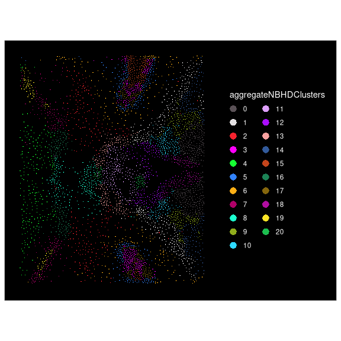

```r
smallXenium$aggregateNBHDClusters = agg@active.ident
ImageDimPlot(smallXenium,group.by='aggregateNBHDClusters',cols='polychrome')
```

Since neighbourhoods here are indexed by individual cells, the neighbourhood gene aggregation Seurat object is formally identical to a standard Seurat object. In particular, this allows the standard sorts of analyses including clustering of neighbourhoods into types; dimension reduction using PCA, UMAP, tSNE; discovery of marker genes for each neighbourhood type; plotting of aggregate gene expression on neighbourhood UMAP; use of CatsCradle to discover novel clustering of genes based on their expression across the different neighbourhoods.

## Neighbourhoods as characterised by cell types

### Calculation of neighbourhood celltype composition

Given any of the spatial graphs describing neighbourhoods calculated above, we can now calculate the cell type composition of neighbourhoods.

```r
NBHDByCTMatrix = computeNBHDByCTMatrix(delaunayNeighbours, clusters)
```

In the resulting matrix neighbourhoods are rows and cell types are columns. The values in the matrix indicate the number of cells of a given type within a neighbourhood.

Let’s do the same for our extended neighbourhoods.

```r
NBHDByCTMatrixExtended =
  computeNBHDByCTMatrix(extendedNeighbours, clusters)
```

### Analysis of contact based interactions between cell types

We can go on to calculate a matrix which gives the fraction of contacts cells of a given type make with cells of another cell type.

```r
cellTypesPerCellTypeMatrix =
  computeCellTypesPerCellTypeMatrix(NBHDByCTMatrix,clusters)
```

Rows and columns both correspond to cell types, but they are playing different roles. For a given row (say, cell type A) the entry in column B represents the fraction of cells in neighbourhoods of cells of type A that are of type B.

We can then display this as a force directed graph. Here we choose only to display contact based interactions that constitute at least 5% of a cell type’s interactions. Of note, this graph is directed as, for example, 50% of cell type A’s interactions might be with cell type B, but only 5% of cell type B’s interactions might be with cell type A.

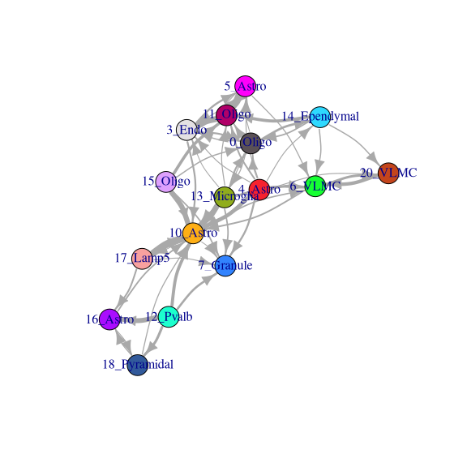

```
#> IGRAPH 09d5e9f DNW- 16 55 --
#> + attr: coords (g/n), name (v/c), color (v/c), weight (e/n), width
#> | (e/n)
#> + edges from 09d5e9f (vertex names):
#>  [1] 0_Oligo->3_Endo       0_Oligo->5_Astro      0_Oligo->10_Astro
#>  [4] 0_Oligo->11_Oligo     0_Oligo->13_Microglia 0_Oligo->14_Ependymal
#>  [7] 3_Endo ->0_Oligo      3_Endo ->5_Astro      3_Endo ->10_Astro
#> [10] 3_Endo ->11_Oligo     4_Astro->0_Oligo      4_Astro->3_Endo
#> [13] 4_Astro->5_Astro      4_Astro->6_VLMC       4_Astro->7_Granule
#> [16] 4_Astro->10_Astro     4_Astro->11_Oligo     4_Astro->14_Ependymal
#> [19] 4_Astro->17_Lamp5     4_Astro->20_VLMC      5_Astro->3_Endo
#> + ... omitted several edges
```

```r
colours = DiscretePalette(length(levels(clusters)), palette = "polychrome")
names(colours) = levels(clusters)

cellTypesPerCellTypeGraphFromCellMatrix(cellTypesPerCellTypeMatrix,
                                    minWeight = 0.05, colours = colours)
```

Here arrows are directed from rows to columns. Thus, we see an arrow from 12_Pvalb to 18_pyramidal because neighbourhoods of cells of type 12_Pvalb are composed (across the dataset) of ~15% cells of type 18_pyramidal. We do not see an arrow from 18_pyramidal to 12_Pvalb because neighbourhoods of cells of type 18_pyramidal have only 3% cells of type 12_Pvalb, which falls below the chosen cutoff.

It’s worth pointing out the following. The number of edges from cells of type A to cells of type B is the same as the number of edges from cells of type B to cells of type A. Thus the matrix of counts of these edges is symmetric. However, numbers of cells of types A and B are not necessarily equal, and this accounts for the assymmetry in the fractions.

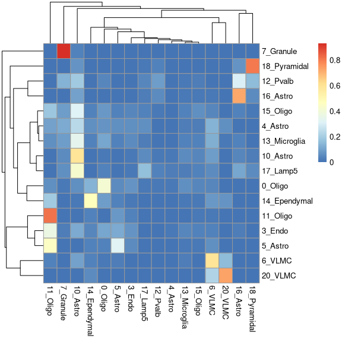

```r
library(pheatmap,quietly=TRUE)
pheatmap(cellTypesPerCellTypeMatrix)
```

Let’s do the same for our extended nighbourhoods.

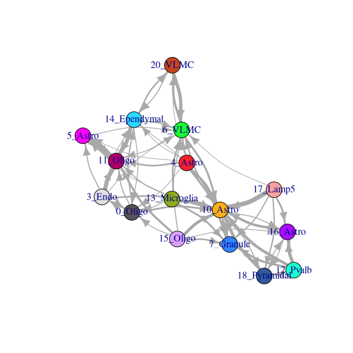

```
#> IGRAPH de83146 DNW- 16 62 --
#> + attr: coords (g/n), name (v/c), color (v/c), weight (e/n), width
#> | (e/n)
#> + edges from de83146 (vertex names):
#>  [1] 0_Oligo->3_Endo       0_Oligo->10_Astro     0_Oligo->11_Oligo
#>  [4] 0_Oligo->14_Ependymal 3_Endo ->0_Oligo      3_Endo ->5_Astro
#>  [7] 3_Endo ->6_VLMC       3_Endo ->10_Astro     3_Endo ->11_Oligo
#> [10] 3_Endo ->14_Ependymal 4_Astro->0_Oligo      4_Astro->5_Astro
#> [13] 4_Astro->6_VLMC       4_Astro->7_Granule    4_Astro->10_Astro
#> [16] 4_Astro->11_Oligo     4_Astro->14_Ependymal 4_Astro->20_VLMC
#> [19] 5_Astro->6_VLMC       5_Astro->11_Oligo     6_VLMC ->10_Astro
#> + ... omitted several edges
```

```r
cellTypesPerCellTypeMatrixExtended = computeCellTypesPerCellTypeMatrix(NBHDByCTMatrixExtended,clusters)

cellTypesPerCellTypeGraphFromCellMatrix(cellTypesPerCellTypeMatrixExtended,
minWeight = 0.05, colours = colours)
```

We can also calculate p values (upper tail, one-sided) for whether cell types are more commonly neighbours than expected by chance. To do this we compare the actual spatial neighbour graph to randomised spatial neighbour graphs where edges are randomised but the degree of each vertice is preserved. As this is carried out on the level of counts of undirected edges between celltypes the p value matrix is symmetric.

```r
cellTypesPerCellTypePValues = computeNeighbourEnrichment(delaunayNeighbours,
                                                     clusters, verbose = FALSE)
```

Let’s plot -log10(pvalue)

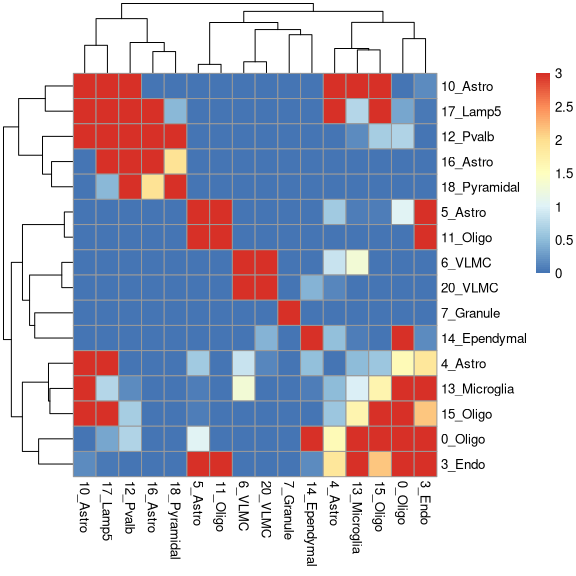

```r
cellTypesPerCellTypePValuesNegLog = -log10(cellTypesPerCellTypePValues)
pheatmap(cellTypesPerCellTypePValuesNegLog)
```

## Analysis of neighbourhoods based on cell type composition

As mentioned above we can create Seurat objects of neighbourhoods where the underlying counts matrix gives the the number of cells of each type in a given neighbourhood. We can now perform dimensionality reduction and clustering based on neighbourhood composition. As the dimensionality of the feature space is relatively low (number of cell types) we calculate the UMAP using features rather than PCs.

```r
NBHDByCTSeurat = computeNBHDVsCTSeurat(NBHDByCTMatrix,verbose=FALSE)
```

Add cell type information to the neighbourhoodSeurat object.

```r
NBHDByCTSeurat$cellType = clusters
```

Visualise neighbourhood clusters.

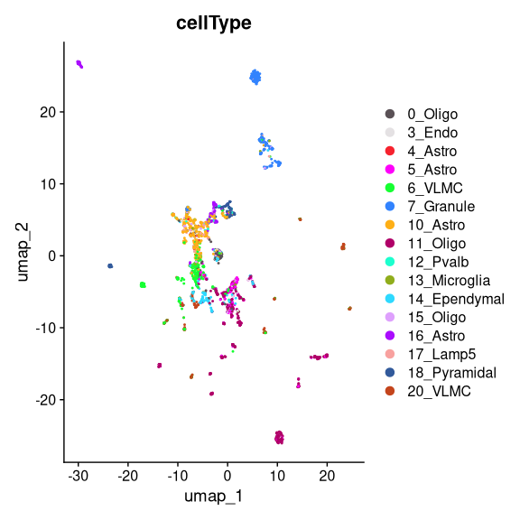

```r
DimPlot(NBHDByCTSeurat, group.by = c("cellType"), cols = "polychrome", reduction = "umap")
```

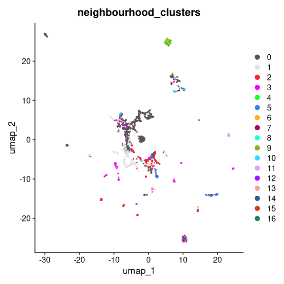

```r
DimPlot(NBHDByCTSeurat, group.by = c("neighbourhood_clusters"), cols = "polychrome", reduction = "umap")
```

We can now add information on neighbourhood clusters to our original Xenium object and visualise these on the tissue.

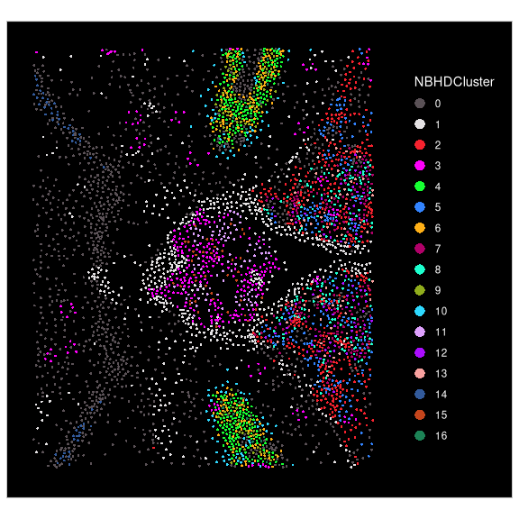

```r
smallXenium$NBHDCluster = NBHDByCTSeurat@active.ident
ImageDimPlot(smallXenium, group.by = "NBHDCluster", size = 1, cols = "polychrome")
```

Let’s try the same thing with our extended neighbourhoods up to degree 4.

```r
NBHDByCTSeuratExtended = computeNBHDVsCTSeurat(NBHDByCTMatrixExtended,
                                               verbose=FALSE)
```

Add cell type information to the NBHDByCTSeuratExtended object.

```r
NBHDByCTSeuratExtended$cellType = clusters
```

Visualise extended neighbourhood clusters.

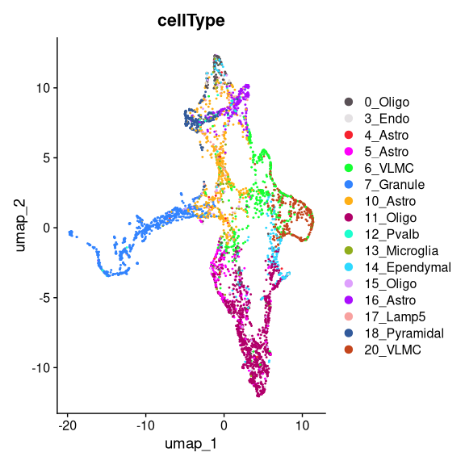

```r
DimPlot(NBHDByCTSeuratExtended, group.by = c("cellType"), cols = "polychrome", reduction = "umap")
```

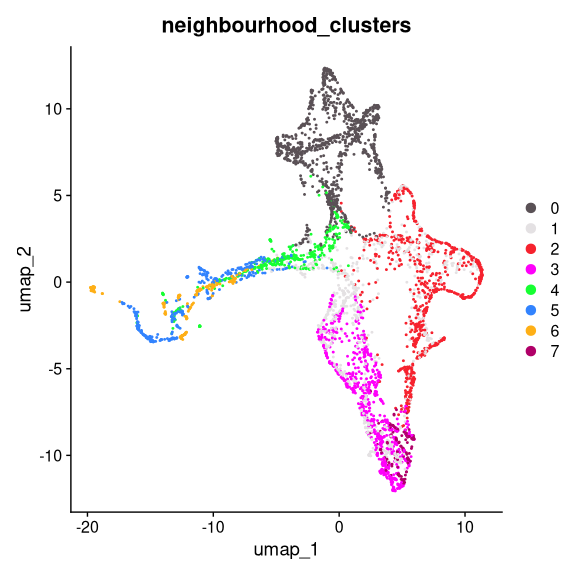

```r
DimPlot(NBHDByCTSeuratExtended, group.by = c("neighbourhood_clusters"), cols = "polychrome", reduction = "umap")
```

We can now add information on extended neighbourhood clusters to our original Xenium object and visualise these on the tissue.

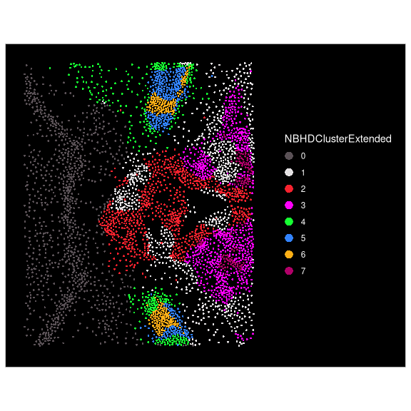

```r
smallXenium$NBHDClusterExtended=
  NBHDByCTSeuratExtended@active.ident
ImageDimPlot(smallXenium, group.by = c("NBHDClusterExtended"),
             size = 1, cols = "polychrome")
```

Here we retrieve fewer clusters, and these describe tissue architecture rather than small variations in cellular niche.

We leave it to the user to decide which approach is most applicable to the biological question at hand.

## Relating cell type clusters to neighbourhood clusters

We can now ask how clusters defined transcriptomically (cell type) relate to those defined based on neighbourhoods (cell niche). Put differently, each cell has its (transcriptomic) cell type and sits at the center of a neighbourhood with a given neighbourhood type. For each cell type A and each neighbourhood type B, we can ask what percentage of the time a cell of type A sits at the center of a neighbourhood of type B.

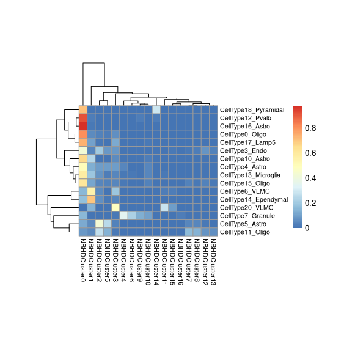

```r
CTByNBHDCluster = table(NBHDByCTSeurat$cellType,NBHDByCTSeurat@active.ident)
CTByNBHDCluster = CTByNBHDCluster/rowSums(CTByNBHDCluster)

rownames(CTByNBHDCluster) = paste0("CellType",rownames(CTByNBHDCluster))
colnames(CTByNBHDCluster) = paste0("NBHDCluster",colnames(CTByNBHDCluster))

pheatmap(CTByNBHDCluster,
      fontsize_row=8,
      fontsize_col=8,
      cellheight=10,
      cellwidth=10)
```

```r
sankeyFromMatrix(CTByNBHDCluster)
```

[interactive chart not shown]

This allows us to see which cell types share the same niche (neighbourhood clusters). Let’s also perform this analysis using the extended neighbourhoods.

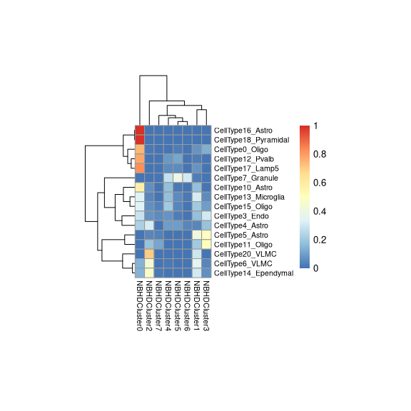

```r
CTByNBHDClusterExtended = table(NBHDByCTSeuratExtended$cellType,NBHDByCTSeuratExtended@active.ident)
CTByNBHDClusterExtended = CTByNBHDClusterExtended/rowSums(CTByNBHDClusterExtended)

rownames(CTByNBHDClusterExtended) = paste0("CellType",rownames(CTByNBHDClusterExtended))
colnames(CTByNBHDClusterExtended) = paste0("NBHDCluster",colnames(CTByNBHDClusterExtended))

pheatmap(CTByNBHDClusterExtended,
      fontsize_row=8,
      fontsize_col=8,
      cellheight=10,
      cellwidth=10)
```

```r
sankeyFromMatrix(CTByNBHDClusterExtended)
```

[interactive chart not shown]

## Analysing cell types based on their neighbourhoods

Now we perform dimensionality reduction and clustering of cell types, based on the neighbourhoods they are found in. Note that this is based on the transpose of the matrix used in the previous section.

First we create a Seurat object for a cell type by neighbourhood matrix (the transposed NBHDByCTMatrix). Here we have a large feature space (number of cells) however a low number of observations (number of cell types). Therefore we compute the UMAP using PCs, however due to the low number of observations we need to set a lower value for n.neighbours.

```r
CTByNBHDSeurat =
  computeNBHDVsCTSeurat(t(NBHDByCTMatrix), npcs = 10,
                        transpose = TRUE, resolution = 1, n.neighbors = 5,
            verbose=FALSE)
```

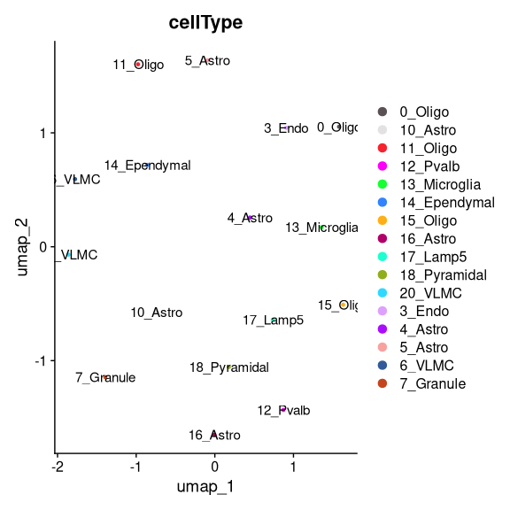

```r
CTByNBHDSeurat$cellType = colnames(CTByNBHDSeurat)

DimPlot(CTByNBHDSeurat, group.by = "cellType", cols = "polychrome",
        reduction = "umap", label = T)
```

Note how Pyramidal, Pvalb and Lamp5 neurons are located close together in UMAP space indicating they are often found in the same neighbourhoods.

We can also compute a force-directed graph embedding.

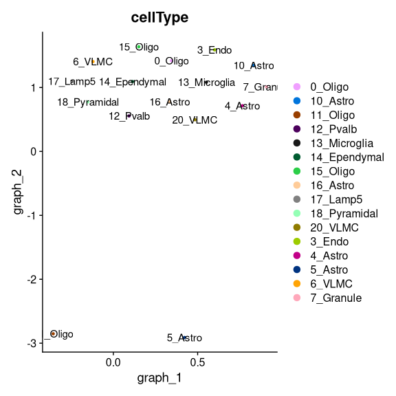

```r
CTByNBHDSeurat= computeGraphEmbedding(CTByNBHDSeurat)
DimPlot(CTByNBHDSeurat,group.by = "cellType", cols = "alphabet", reduction = "graph", label = T)
```

From this 11_oligo and 5_Astro appear to be in neighbourhoods distinct from the other cell types. Looking at cell type localisation in the tissue shows that they colocalise.

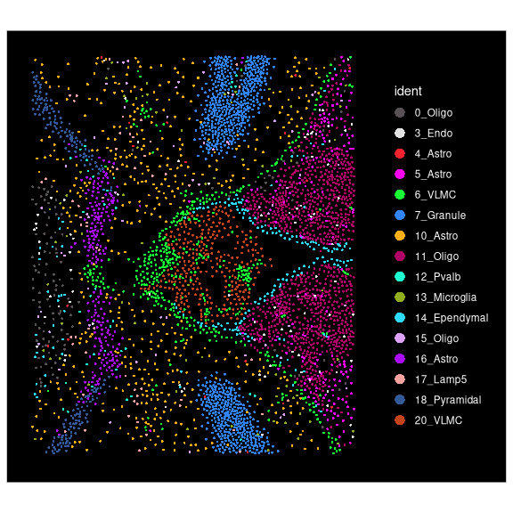

```r
ImageDimPlot(smallXenium, cols = "polychrome", size = 1)
```

Clustering cell types using the Louvain algorithm acheives only one cluster. Let’s try hierachical clustering.

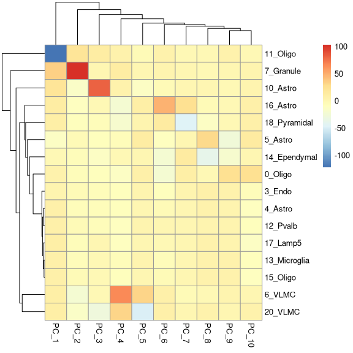

```r
pca = Embeddings(CTByNBHDSeurat, reduction = "pca")
res = pheatmap(pca)
```

Here we decide to cut the tree at the correct level to form 11 clusters.

```r
CTClust = cutree(res$tree_row, k = 11)
CTByNBHDSeurat$neighbourhood_clusters = factor(CTClust)
```

Let’s look at the celltype composition of these clusters.

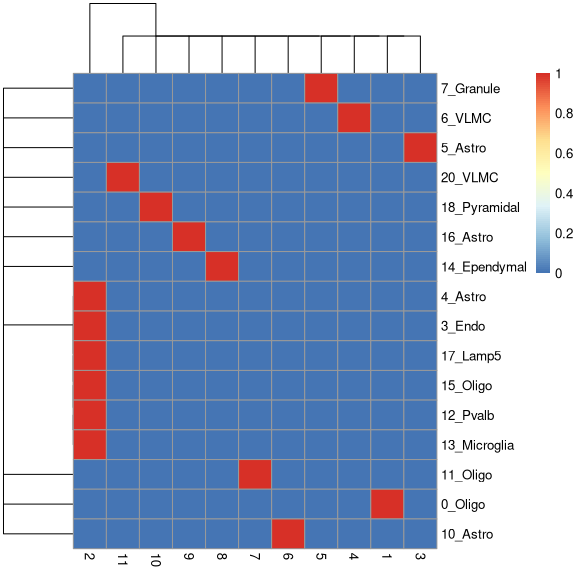

```r
CTComposition = table(CTByNBHDSeurat$cellType, CTByNBHDSeurat$neighbourhood_clusters)
pheatmap(CTComposition)
```

Although most clusters here are formed of a single cell type, cluster 2 contains several cell types. We anticipate this analysis may be more informative when performed on a larger tissue area, as some cell types are poorly represented in this subset. To this end we demonstrate how to explore the relationship between neighbourhood clusters and cell type clusters.

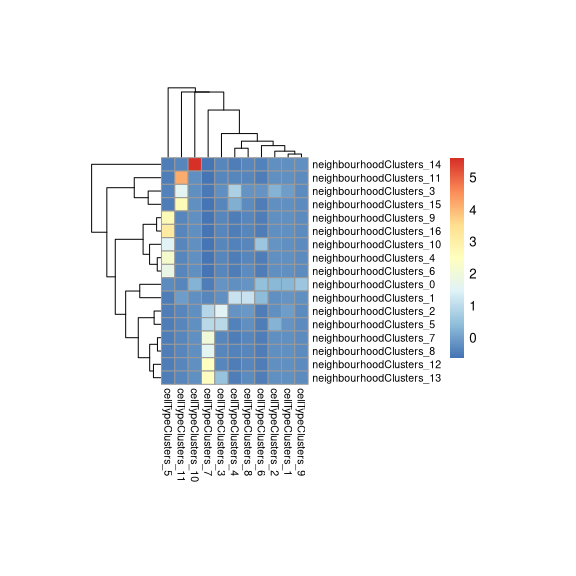

```r
averageExpMatrix = getAverageExpressionMatrix(NBHDByCTSeurat,
                           CTByNBHDSeurat,
                clusteringName='neighbourhood_clusters')
averageExpMatrix = tagRowAndColNames(averageExpMatrix,
                                     ccTag='neighbourhoodClusters_',
                                     gcTag='cellTypeClusters_')
pheatmap(averageExpMatrix,
      fontsize_row=8,
      fontsize_col=8,
      cellheight=10,
      cellwidth=10)
```

```r
sankeyFromMatrix(averageExpMatrix)
```

[interactive chart not shown]

## Detection of genes with spatially variable expression.

Given a neighbour graph describing the spatial relationships between cells, we can compute spatial autocorrelation (here we use Moran’s I). This describes how clustered gene expression values are in space. We derive an upper tail p value based on permutation testing where expression values for genes are permuted. N.B in this implementation equal weights are given to all neighbours of a cell.

```r
moransI = runMoransI(smallXenium, delaunayNeighbours, assay = "SCT",
                     layer = "data", nSim = 100, verbose = FALSE)
```

Look at most spatially autocorrelated genes.

```r
head(moransI)
```

```
#>                 moransI pValues
#> Nwd2          0.8759895    0.01
#> Neurod6       0.8592572    0.01
#> 2010300C02Rik 0.8232980    0.01
#> Cabp7         0.8084018    0.01
#> Epha4         0.8058667    0.01
#> Bhlhe22       0.8050729    0.01
```

Look at least spatially autocorrelated genes.

```r
tail(moransI)
```

```
#>            moransI pValues
#> Arhgap25 0.1602768    0.02
#> Myl4     0.1519870    0.20
#> Gm19410  0.1517466    0.20
#> Rxfp1    0.1509323    0.20
#> Opn3     0.1497122    0.27
#> Trbc2    0.1294289    0.94
```

Here we visualise the most spatially autocorrelated gene.

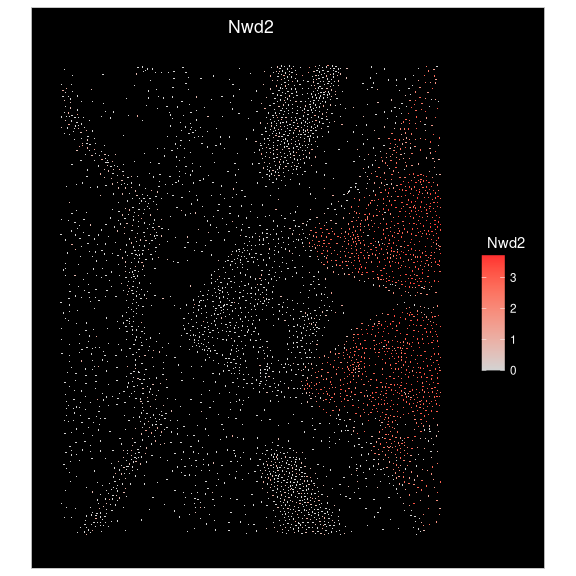

```r
ImageFeaturePlot(smallXenium, "Nwd2")
```

Here we visualise the least spatially autocorrelated gene.

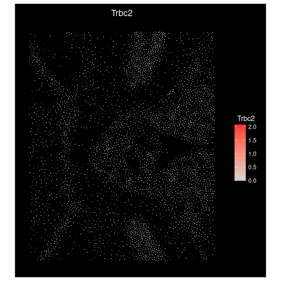

```r
ImageFeaturePlot(smallXenium, "Trbc2")
```

## Ligand receptor analysis

We can perform an analysis of ligand receptor interactions in order to infer communication between cells. Here we calculate whether interactions between ligand receptor pairs occur on edges of the spatial graph, i.e. between neighbouring cells, where cell A expresses a ligand and cell B expresses a receptor. Note that the distance between cell A and cell B will vary depending on how the graph has been constructed, larger distances may be desired for analyses involving diffusable ligands. We also analyse the number of ligand receptor interactions that occur between cells from the same cluster and between cells from different clusters. Note that clusters may represent cell type, or another property of the cells such as their neighbourhood type. We leave this for the user to decide. We then calculate how frequently the number of ligand-receptor interactions observed between/within clusters is higher than in simulated data - this allows us to assign a pvalue for the enrichment of these interactions.

```r
ligandReceptorResults = performLigandReceptorAnalysis(smallXenium, delaunayNeighbours,
                                                "mouse", clusters,verbose=FALSE)
```

We look at interactions on edges. For concision, we display the first six of our 28 ligand-receptor pairs. Since ligand-receptor interactions are directed, each undirected edge will show up both as cell A - cell B and as cell B - cell A.

```r
head(ligandReceptorResults$interactionsOnEdges[,1:10],10)
```

```
#>        clusterA     clusterB nodeA nodeB Pecam1-Pecam1 Cdh4-Cdh4 Col1a1-Cd44
#> 1        6_VLMC     11_Oligo 16307 16316          TRUE     FALSE       FALSE
#> 2       5_Astro      5_Astro 16314 16317         FALSE     FALSE       FALSE
#> 3        6_VLMC       6_VLMC 16296 16299         FALSE     FALSE       FALSE
#> 4        6_VLMC       6_VLMC 16299 16307          TRUE     FALSE       FALSE
#> 5       5_Astro     11_Oligo 16309 16316         FALSE      TRUE       FALSE
#> 6       5_Astro      5_Astro 16309 16314         FALSE     FALSE       FALSE
#> 7  18_Pyramidal 18_Pyramidal 12028 12032         FALSE     FALSE       FALSE
#> 8  18_Pyramidal    7_Granule 12032 16914         FALSE     FALSE       FALSE
#> 9  18_Pyramidal    7_Granule 12032 16257         FALSE     FALSE       FALSE
#> 10      4_Astro    7_Granule  2975  3339         FALSE     FALSE       FALSE
#>    Fn1-Cd44 Spp1-Cd44 Cort-Npy2r
#> 1     FALSE     FALSE      FALSE
#> 2     FALSE     FALSE      FALSE
#> 3     FALSE     FALSE      FALSE
#> 4     FALSE     FALSE      FALSE
#> 5     FALSE     FALSE      FALSE
#> 6     FALSE     FALSE      FALSE
#> 7     FALSE     FALSE      FALSE
#> 8     FALSE     FALSE      FALSE
#> 9     FALSE     FALSE      FALSE
#> 10    FALSE     FALSE      FALSE
```

Look at total interactions between/within clusters:

```r
head(ligandReceptorResults$totalInteractionsByCluster[,1:10],10)
```

```
#>                               clusterPair totalEdges Pecam1-Pecam1 Cdh4-Cdh4
#> 0_Oligo-0_Oligo           0_Oligo-0_Oligo        310             2         2
#> 0_Oligo-10_Astro         0_Oligo-10_Astro         44             1         5
#> 0_Oligo-11_Oligo         0_Oligo-11_Oligo         44             1         0
#> 0_Oligo-12_Pvalb         0_Oligo-12_Pvalb          9             0         3
#> 0_Oligo-13_Microglia 0_Oligo-13_Microglia         45             4         0
#> 0_Oligo-14_Ependymal 0_Oligo-14_Ependymal        103             2         1
#> 0_Oligo-15_Oligo         0_Oligo-15_Oligo         29             0         0
#> 0_Oligo-16_Astro         0_Oligo-16_Astro          2             0         0
#> 0_Oligo-17_Lamp5         0_Oligo-17_Lamp5         11             0         0
#> 0_Oligo-18_Pyramidal 0_Oligo-18_Pyramidal          4             0         0
#>                      Col1a1-Cd44 Fn1-Cd44 Spp1-Cd44 Cort-Npy2r Cort-Htr1f
#> 0_Oligo-0_Oligo                2        3         0          0          0
#> 0_Oligo-10_Astro               0        1         0          0          0
#> 0_Oligo-11_Oligo               0        0         0          0          0
#> 0_Oligo-12_Pvalb               0        0         0          0          0
#> 0_Oligo-13_Microglia           0        0         1          0          0
#> 0_Oligo-14_Ependymal           0        6         0          0          0
#> 0_Oligo-15_Oligo               0        0         0          0          0
#> 0_Oligo-16_Astro               0        0         0          0          0
#> 0_Oligo-17_Lamp5               0        0         0          0          0
#> 0_Oligo-18_Pyramidal           0        0         0          0          0
#>                      Cort-Chrm2
#> 0_Oligo-0_Oligo               3
#> 0_Oligo-10_Astro              2
#> 0_Oligo-11_Oligo              1
#> 0_Oligo-12_Pvalb              0
#> 0_Oligo-13_Microglia          0
#> 0_Oligo-14_Ependymal          2
#> 0_Oligo-15_Oligo              1
#> 0_Oligo-16_Astro              0
#> 0_Oligo-17_Lamp5              0
#> 0_Oligo-18_Pyramidal          0
```

Look at mean interactions per edge between/within clusters (sum of ligand receptor interactions on A-B edges)/(total A-B edges):

```r
head(ligandReceptorResults$meanInteractionsByCluster[,1:10],10)
```

```
#>                               clusterPair totalEdges Pecam1-Pecam1   Cdh4-Cdh4
#> 0_Oligo-0_Oligo           0_Oligo-0_Oligo        310   0.006451613 0.006451613
#> 0_Oligo-10_Astro         0_Oligo-10_Astro         44   0.022727273 0.113636364
#> 0_Oligo-11_Oligo         0_Oligo-11_Oligo         44   0.022727273 0.000000000
#> 0_Oligo-12_Pvalb         0_Oligo-12_Pvalb          9   0.000000000 0.333333333
#> 0_Oligo-13_Microglia 0_Oligo-13_Microglia         45   0.088888889 0.000000000
#> 0_Oligo-14_Ependymal 0_Oligo-14_Ependymal        103   0.019417476 0.009708738
#> 0_Oligo-15_Oligo         0_Oligo-15_Oligo         29   0.000000000 0.000000000
#> 0_Oligo-16_Astro         0_Oligo-16_Astro          2   0.000000000 0.000000000
#> 0_Oligo-17_Lamp5         0_Oligo-17_Lamp5         11   0.000000000 0.000000000
#> 0_Oligo-18_Pyramidal 0_Oligo-18_Pyramidal          4   0.000000000 0.000000000
#>                      Col1a1-Cd44    Fn1-Cd44  Spp1-Cd44 Cort-Npy2r Cort-Htr1f
#> 0_Oligo-0_Oligo      0.006451613 0.009677419 0.00000000          0          0
#> 0_Oligo-10_Astro     0.000000000 0.022727273 0.00000000          0          0
#> 0_Oligo-11_Oligo     0.000000000 0.000000000 0.00000000          0          0
#> 0_Oligo-12_Pvalb     0.000000000 0.000000000 0.00000000          0          0
#> 0_Oligo-13_Microglia 0.000000000 0.000000000 0.02222222          0          0
#> 0_Oligo-14_Ependymal 0.000000000 0.058252427 0.00000000          0          0
#> 0_Oligo-15_Oligo     0.000000000 0.000000000 0.00000000          0          0
#> 0_Oligo-16_Astro     0.000000000 0.000000000 0.00000000          0          0
#> 0_Oligo-17_Lamp5     0.000000000 0.000000000 0.00000000          0          0
#> 0_Oligo-18_Pyramidal 0.000000000 0.000000000 0.00000000          0          0
#>                       Cort-Chrm2
#> 0_Oligo-0_Oligo      0.009677419
#> 0_Oligo-10_Astro     0.045454545
#> 0_Oligo-11_Oligo     0.022727273
#> 0_Oligo-12_Pvalb     0.000000000
#> 0_Oligo-13_Microglia 0.000000000
#> 0_Oligo-14_Ependymal 0.019417476
#> 0_Oligo-15_Oligo     0.034482759
#> 0_Oligo-16_Astro     0.000000000
#> 0_Oligo-17_Lamp5     0.000000000
#> 0_Oligo-18_Pyramidal 0.000000000
```

Look at number of times observed interactions are more frequent than expected:

```r
head(ligandReceptorResults$simResults[,1:10],10)
```

```
#>                      Pecam1-Pecam1 Cdh4-Cdh4 Col1a1-Cd44 Fn1-Cd44 Spp1-Cd44
#> 0_Oligo-0_Oligo                 14       375         243      220         0
#> 0_Oligo-10_Astro               275      1000           0      534         0
#> 0_Oligo-11_Oligo               299         0           0        0         0
#> 0_Oligo-12_Pvalb                 0      1000           0        0         0
#> 0_Oligo-13_Microglia           889         0           0        0       800
#> 0_Oligo-14_Ependymal           210       528           0      982         0
#> 0_Oligo-15_Oligo                 0         0           0        0         0
#> 0_Oligo-16_Astro                 0         0           0        0         0
#> 0_Oligo-17_Lamp5                 0         0           0        0         0
#> 0_Oligo-18_Pyramidal             0         0           0        0         0
#>                      Cort-Npy2r Cort-Htr1f Cort-Chrm2 Cort-Gpr17 Sst-Npy2r
#> 0_Oligo-0_Oligo               0          0        650        902         0
#> 0_Oligo-10_Astro              0          0        951        868         0
#> 0_Oligo-11_Oligo              0          0        798          0         0
#> 0_Oligo-12_Pvalb              0          0          0          0         0
#> 0_Oligo-13_Microglia          0          0          0          0         0
#> 0_Oligo-14_Ependymal          0          0        843        737         0
#> 0_Oligo-15_Oligo              0          0        814        991         0
#> 0_Oligo-16_Astro              0          0          0          0         0
#> 0_Oligo-17_Lamp5              0          0          0          0         0
#> 0_Oligo-18_Pyramidal          0          0          0          0         0
```

Look at pvalues (upper tail) for the enrichment of interactions.

```r
head(ligandReceptorResults$pValues,10)
```

```
#>                      Pecam1-Pecam1 Cdh4-Cdh4 Col1a1-Cd44 Fn1-Cd44 Spp1-Cd44
#> 0_Oligo-0_Oligo              0.986     0.625       0.757    0.780       1.0
#> 0_Oligo-10_Astro             0.725     0.001       1.000    0.466       1.0
#> 0_Oligo-11_Oligo             0.701     1.000       1.000    1.000       1.0
#> 0_Oligo-12_Pvalb             1.000     0.001       1.000    1.000       1.0
#> 0_Oligo-13_Microglia         0.111     1.000       1.000    1.000       0.2
#> 0_Oligo-14_Ependymal         0.790     0.472       1.000    0.018       1.0
#> 0_Oligo-15_Oligo             1.000     1.000       1.000    1.000       1.0
#> 0_Oligo-16_Astro             1.000     1.000       1.000    1.000       1.0
#> 0_Oligo-17_Lamp5             1.000     1.000       1.000    1.000       1.0
#> 0_Oligo-18_Pyramidal         1.000     1.000       1.000    1.000       1.0
#>                      Cort-Npy2r Cort-Htr1f Cort-Chrm2 Cort-Gpr17 Sst-Npy2r
#> 0_Oligo-0_Oligo               1          1      0.350      0.098         1
#> 0_Oligo-10_Astro              1          1      0.049      0.132         1
#> 0_Oligo-11_Oligo              1          1      0.202      1.000         1
#> 0_Oligo-12_Pvalb              1          1      1.000      1.000         1
#> 0_Oligo-13_Microglia          1          1      1.000      1.000         1
#> 0_Oligo-14_Ependymal          1          1      0.157      0.263         1
#> 0_Oligo-15_Oligo              1          1      0.186      0.009         1
#> 0_Oligo-16_Astro              1          1      1.000      1.000         1
#> 0_Oligo-17_Lamp5              1          1      1.000      1.000         1
#> 0_Oligo-18_Pyramidal          1          1      1.000      1.000         1
#>                      Sst-Htr1f Sst-Chrm2 Sst-Gpr17 Nts-Ntsr2 Nts-Tacr1
#> 0_Oligo-0_Oligo          1.000     0.002     0.001     0.055     1.000
#> 0_Oligo-10_Astro         1.000     0.075     1.000     1.000     1.000
#> 0_Oligo-11_Oligo         1.000     1.000     1.000     1.000     0.001
#> 0_Oligo-12_Pvalb         1.000     1.000     1.000     1.000     1.000
#> 0_Oligo-13_Microglia     0.041     0.072     0.045     0.056     1.000
#> 0_Oligo-14_Ependymal     1.000     1.000     1.000     0.020     1.000
#> 0_Oligo-15_Oligo         1.000     1.000     0.029     0.031     1.000
#> 0_Oligo-16_Astro         1.000     1.000     1.000     1.000     1.000
#> 0_Oligo-17_Lamp5         1.000     1.000     1.000     1.000     1.000
#> 0_Oligo-18_Pyramidal     1.000     1.000     1.000     1.000     1.000
#>                      Nts-Gpr17 Pthlh-Rxfp1 Crh-Rxfp1 Penk-Npy2r Penk-Htr1f
#> 0_Oligo-0_Oligo          0.008           1         1          1      0.354
#> 0_Oligo-10_Astro         1.000           1         1          1      0.266
#> 0_Oligo-11_Oligo         0.052           1         1          1      1.000
#> 0_Oligo-12_Pvalb         1.000           1         1          1      1.000
#> 0_Oligo-13_Microglia     1.000           1         1          1      1.000
#> 0_Oligo-14_Ependymal     0.123           1         1          1      1.000
```

[output cut: 11 more lines]

```
#> 0_Oligo-15_Oligo          0.025      0.004          1          1      1.000
#> 0_Oligo-16_Astro          1.000      1.000          1          1      1.000
#> 0_Oligo-17_Lamp5          1.000      1.000          1          1      1.000
#> 0_Oligo-18_Pyramidal      1.000      1.000          1          1      1.000
#>                      Pdyn-Gpr17 Vip-Rxfp1 Cdh6-Cdh9
#> 0_Oligo-0_Oligo           0.867     0.011     1.000
#> 0_Oligo-10_Astro          1.000     1.000     1.000
#> 0_Oligo-11_Oligo          1.000     1.000     0.598
#> 0_Oligo-12_Pvalb          1.000     1.000     1.000
#> 0_Oligo-13_Microglia      1.000     1.000     1.000
#> 0_Oligo-14_Ependymal      1.000     0.031     0.901
#> 0_Oligo-15_Oligo          1.000     1.000     0.464
#> 0_Oligo-16_Astro          1.000     1.000     1.000
#> 0_Oligo-17_Lamp5          1.000     1.000     1.000
#> 0_Oligo-18_Pyramidal      1.000     1.000     1.000
```

Plot a heatmap showing -log10(pvalues) for the enrichment of ligand-receptor interactions between pairs of clusters.

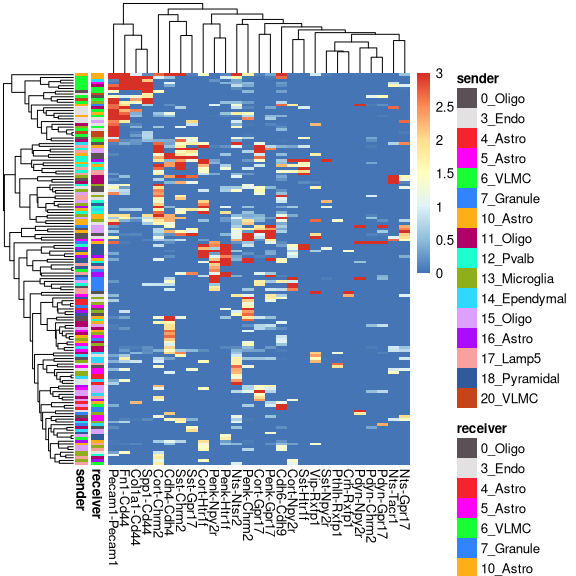

```r
ligRecMatrix = makeLRInteractionHeatmap(ligandReceptorResults, clusters, colours = colours, labelClusterPairs = F)
```

Make a heatmap of total ligand-receptor interactions between clusters.

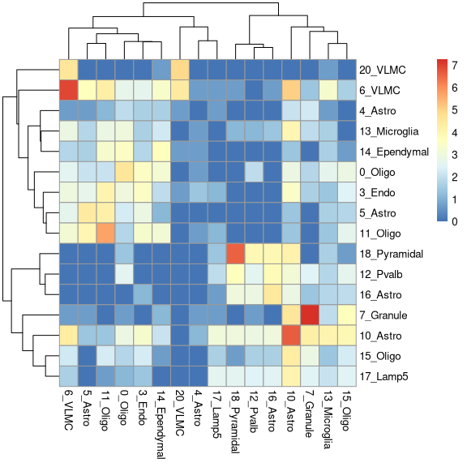

```r
cellTypePerCellTypeLigRecMatrix = makeSummedLRInteractionHeatmap(ligandReceptorResults, clusters, "total")
```

Make a heatmap of summed mean ligand/receptor interactions between clusters i.e., (sum of all ligand receptor interactions on A-B edges)/(total A-B edges)

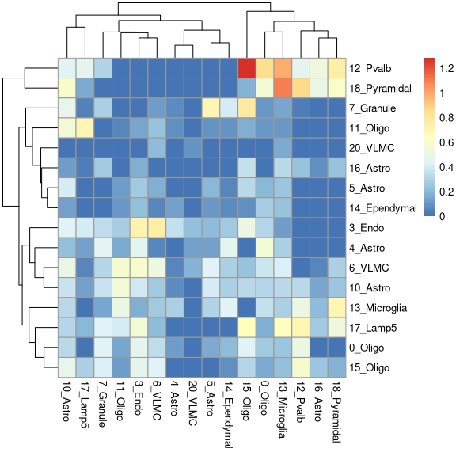

```r
cellTypePerCellTypeLigRecMatrix = makeSummedLRInteractionHeatmap(ligandReceptorResults, clusters, "mean", logScale = T)
```

Look at a histogram of values for summed mean ligand/receptor interactions between clusters.

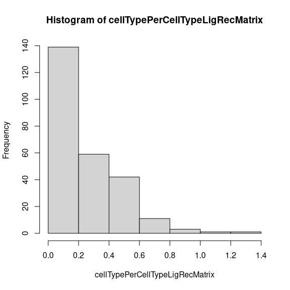

```r
hist(cellTypePerCellTypeLigRecMatrix)
```

Visualise in graph format.

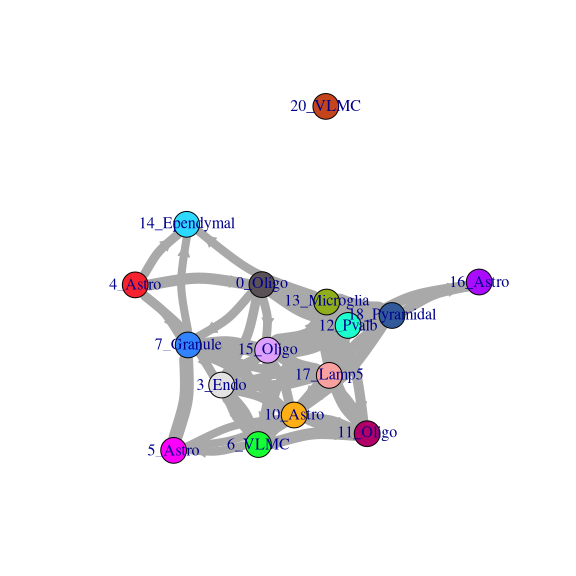

```
#> IGRAPH 6e0e75d DNW- 16 54 --
#> + attr: coords (g/n), name (v/c), color (v/c), weight (e/n), width
#> | (e/n)
#> + edges from 6e0e75d (vertex names):
#>  [1] 0_Oligo  ->3_Endo       0_Oligo  ->7_Granule    0_Oligo  ->12_Pvalb
#>  [4] 0_Oligo  ->15_Oligo     3_Endo   ->6_VLMC       3_Endo   ->10_Astro
#>  [7] 3_Endo   ->15_Oligo     3_Endo   ->17_Lamp5     4_Astro  ->0_Oligo
#> [10] 4_Astro  ->3_Endo       4_Astro  ->7_Granule    4_Astro  ->14_Ependymal
#> [13] 5_Astro  ->10_Astro     6_VLMC   ->3_Endo       6_VLMC   ->5_Astro
#> [16] 6_VLMC   ->10_Astro     6_VLMC   ->11_Oligo     6_VLMC   ->13_Microglia
#> [19] 7_Granule->5_Astro      7_Granule->10_Astro     7_Granule->14_Ependymal
#> + ... omitted several edges
```

```r
cellTypesPerCellTypeGraphFromCellMatrix(cellTypePerCellTypeLigRecMatrix,
                                    minWeight = 0.4, colours = colours)
```

Here the arrows are very thick - we can scale by a constant factor to improve the presentation.

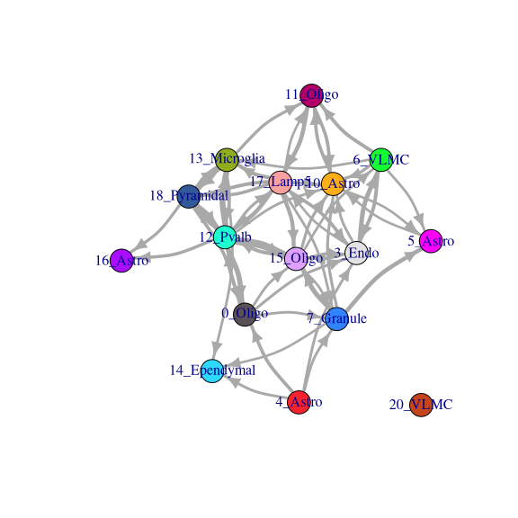

```
#> IGRAPH c13f05d DNW- 16 54 --
#> + attr: coords (g/n), name (v/c), color (v/c), weight (e/n), width
#> | (e/n)
#> + edges from c13f05d (vertex names):
#>  [1] 0_Oligo  ->3_Endo       0_Oligo  ->7_Granule    0_Oligo  ->12_Pvalb
#>  [4] 0_Oligo  ->15_Oligo     3_Endo   ->6_VLMC       3_Endo   ->10_Astro
#>  [7] 3_Endo   ->15_Oligo     3_Endo   ->17_Lamp5     4_Astro  ->0_Oligo
#> [10] 4_Astro  ->3_Endo       4_Astro  ->7_Granule    4_Astro  ->14_Ependymal
#> [13] 5_Astro  ->10_Astro     6_VLMC   ->3_Endo       6_VLMC   ->5_Astro
#> [16] 6_VLMC   ->10_Astro     6_VLMC   ->11_Oligo     6_VLMC   ->13_Microglia
#> [19] 7_Granule->5_Astro      7_Granule->10_Astro     7_Granule->14_Ependymal
#> + ... omitted several edges
```

```r
scaleFactor = 3
cellTypesPerCellTypeGraphFromCellMatrix(cellTypePerCellTypeLigRecMatrix/scaleFactor,
                                    minWeight = 0.4/scaleFactor, colours = colours)
```

### Visualising ligand-receptor interactions: Seurat objects of edges

We wish to create a Seurat object where the points are edges between cells as a way of visualising ligand-receptor interactions. Since these interactions are asymmetric we need to consider directed edges. We will place the spatial coordinates of the edges A-B and B-A slightly separate but both between the centroids of cells A and B. The “expression matrix” is the binarised presence/absence of an interaction (ligand receptor pair) on an edge. This is useful for visualising where ligand receptor interactions occur spatially.

```r
edgeSeurat = computeEdgeSeurat(ligandReceptorResults, centroids)
```

For example we can visualise the Pdyn-Npy2r interaction.

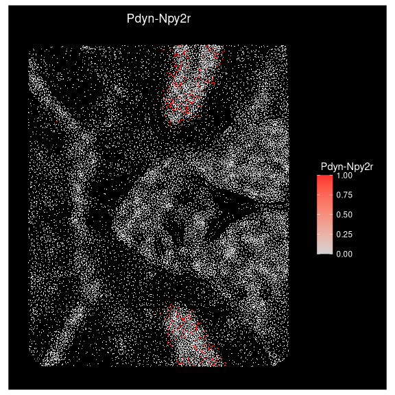

```r
ImageFeaturePlot(edgeSeurat, features = "Pdyn-Npy2r")
```

In principle, the edge Seurat object allows for the computation of an edge UMAP and Louvain clustering of the edges based on ligand-receptor interaction. However some of these analyses are computationally expensive due to large number of edges.

### Spatial autocorrelation of ligand-receptor interactions

We can compute a spatial graph where edges in the original delaunayNeighbours become nodes and A-B edges (in the original graph) become connected to all A- edges and all B- edges. This allows us to perfom graph-based analyses associated with the spatial localisation of ligand receptor pairs on edges.

```r
edgeNeighbours = computeEdgeGraph(delaunayNeighbours)
```

Compute Moran’s I for the spatial autocorrelation of ligand-receptor interactions.

```r
moransILigandReceptor = runMoransI(edgeSeurat, edgeNeighbours, assay = "RNA",
                     layer = "counts", nSim = 100)
```

View most spatially autocorrelated ligand-receptor interactions.

```r
head(moransILigandReceptor)
```

```
#>                 moransI pValues
#> Penk-Htr1f    0.8392801    0.01
#> Vip-Rxfp1     0.7866141    0.02
#> Pthlh-Rxfp1   0.7812148    0.21
#> Pdyn-Npy2r    0.7593318    0.01
#> Nts-Ntsr2     0.7582268    0.01
#> Pecam1-Pecam1 0.7397425    0.01
```

View least spatially autocorrelated ligand-receptor interactions.

```r
tail(moransILigandReceptor)
```

```
#>             moransI pValues
#> Spp1-Cd44 0.6559306    0.01
#> Nts-Tacr1 0.6388787    0.13
#> Nts-Gpr17 0.5903279    0.51
#> Sst-Npy2r 0.5636993    0.58
#> Sst-Htr1f 0.5442672    0.71
#> Sst-Gpr17 0.5305249    0.75
```

View ligand-receptor interaction with the highest spatial autocorrelation (Moran’s I).

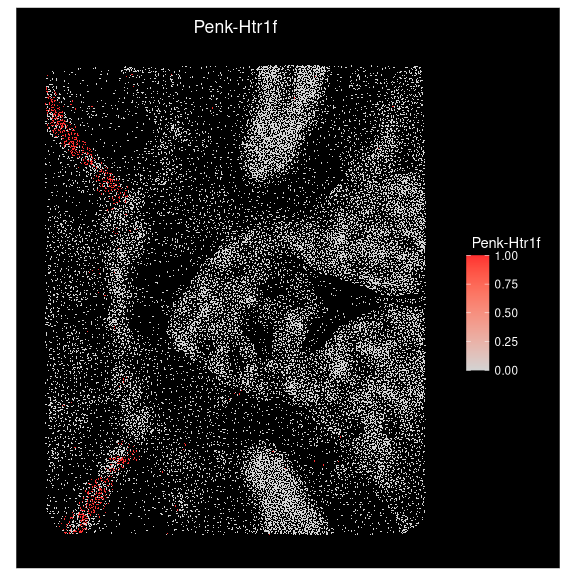

```r
ImageFeaturePlot(edgeSeurat, "Penk-Htr1f")
```

View ligand-receptor interaction with the lowest spatial autocorrelation (Moran’s I).

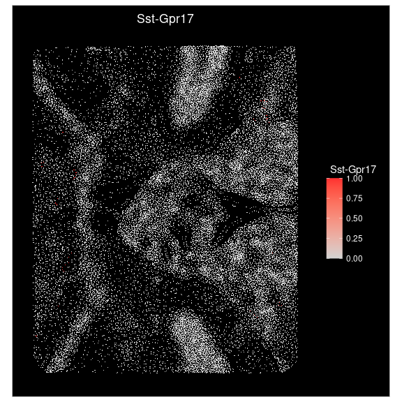

```r
ImageFeaturePlot(edgeSeurat, "Sst-Gpr17")
```